# Dragon Ball Supervised Learning Classification

## Building the model

Models

- Logistic Regression
- K-Nearest Neighbors (K-NN)

### Logistic Regression

- Logistic Regression is a supervised learning algorithm, generally used for binary classification problems, i.e., where the dependent variable is categorical and has only two possible values. In logistic regression, we use the sigmoid function to calculate the probability of an event

```python
from sklearn.linear_model import LogisticRegression

# Fitting the logistic regression model
lg = LogisticRegression()

# Use train data
lg.fit(x_train, y_train)
```

```
LogisticRegression()
```

Checking the model performance

```
              precision    recall  f1-score   support

           0       0.96      1.00      0.98        26
           1       1.00      0.96      0.98        26

    accuracy                           0.98        52
   macro avg       0.98      0.98      0.98        52
weighted avg       0.98      0.98      0.98        52
```

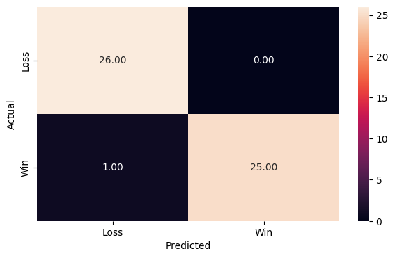

```python
from sklearn.metrics import classification_report, confusion_matrix

# Checking the performance on the training data
y_pred_train = lg.predict(x_train)

metrics_score(y_train, y_pred_train)
```

```
              precision    recall  f1-score   support

           0       1.00      1.00      1.00         7
           1       1.00      1.00      1.00         6

    accuracy                           1.00        13
   macro avg       1.00      1.00      1.00        13
weighted avg       1.00      1.00      1.00        13
```

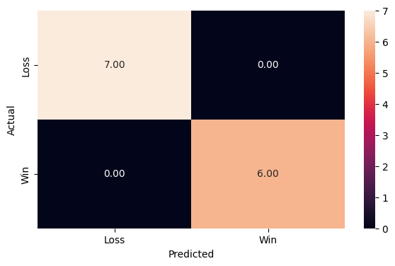

```python
# Checking the performance on the test dataset
y_pred_test = lg.predict(x_test)

metrics_score(y_test, y_pred_test)
```

**Model Evaluation:**

- **False Positive (FP)**: Predicting a character will win when they actually lose.
- **False Negative (FN)**: Predicting a character will lose when they actually win.

For our **Character Battle Outcome Prediction**, **False Negatives (FN)** are more critical because:

- FN means a strong character is mistakenly classified as a weak one.
- This leads to **underestimating contenders**, affecting tournament rankings.
- Missing a winning character can disrupt predictions for battle matchups.

**Chosen Metric: Recall (Sensitivity / True Positive Rate)**

- **Recall** is the percentage of actual wins (True Positives) correctly classified by the model.
- **Formula:**  
  [ Recall = \frac{TP}{TP + FN} ]
- Higher Recall ensures fewer **False Negatives**, meaning **strong contenders are correctly identified**.

**Model Results:**

| **Metric** | **Training Data** | **Test Data** |
| --- | --- | --- |
| **Accuracy** | 98% | 100% |
| **Precision** | 96-100% | 100% |
| **Recall** | 96-100% | 100% |
| **False Positives (FP)** | 0 | 0 |
| **False Negatives (FN)** | 1 | 0 |

**Observations**

- **High Recall ensures that strong characters are not underestimated.**
- **False Negatives are minimized, which aligns with our goal.**
- Our model achieves near-perfect classification, but further testing with different algorithms may help avoid overfitting.

Check the coefficients to identify which variables contribute to a character's likelihood of winning or losing a battle and determine which factors can improve battle predictions

- List of most important features sorted

```python
# Printing the coefficients of logistic regression
cols = X.columns

coef_lg = lg.coef_

pd.DataFrame(coef_lg,columns = cols).T.sort_values(by = 0, ascending = False)
```

|  | 0 |
| --- | --- |
| Power Level | 1.939756 |
| Speed | 0.936487 |
| Transformation_Level | 0.870957 |
| Race_Android | 0.532717 |
| Race_Kai | 0.521403 |
| ... | ... |
| Race_Cell Jr. Attack | -0.341425 |
| Race_Power Blitz | -0.403631 |
| Race_Spinning Blade | -0.432354 |
| Race_Pui Pui Kick | -0.432354 |
| Race_Human | -1.176369 |

135 rows × 1 columns

- E.g.,
  - If two equal attributed characters are battling, the character with the higher speed is likely to win
  - The coefficient of 0.936487 for Speed in the logistic regression model means that for every 1-unit increase in Speed (while keeping all other variables constant), the log-odds of winning increase by approximately 0.9365.

The coefficients of the logistic regression model give us the log of odds, which is hard to interpret in the real world. We can convert the log of odds into odds by taking its exponential.

```python
odds = np.exp(lg.coef_[0]) # Finding the odds

# Adding the odds to a DataFrame and sorting the values
pd.DataFrame(odds, x_train.columns, columns = ['odds']).sort_values(by = 'odds', ascending = False)
```

|  | odds |
| --- | --- |
| Power Level | 6.957055 |
| Speed | 2.551005 |
| Transformation_Level | 2.389196 |
| Race_Android | 1.703555 |
| Race_Kai | 1.684389 |
| ... | ... |
| Race_Cell Jr. Attack | 0.710757 |
| Race_Power Blitz | 0.667891 |
| Race_Spinning Blade | 0.648980 |
| Race_Pui Pui Kick | 0.648980 |
| Race_Human | 0.308397 |

135 rows × 1 columns

- Observations
  - Power Level Has the Highest Impact (Odds: 6.96)
    - A character with a higher Power Level has the highest increase in odds of winning a battle.
    - A 1-unit increase in Power Level multiplies the odds of winning by 6.96 times, making it the strongest predictor.
  - Transformation Level Also Plays a Significant Role (Odds: 2.39)
    - A character's Transformation Level impacts their odds, meaning higher-level transformations significantly improve winning chances.
  - Certain Races Have a Higher Impact Than Others
    - Race_Android (Odds: 1.70) and Race_Kai (Odds: 1.68) have a higher likelihood of winning than other races.
  - Some Attacks and Abilities Have Low or Negative Effects
    - Race_Cell Jr. Attack (Odds: 0.71), Race_Power Blitz (Odds: 0.67), and Race_Spinning Blade (Odds: 0.64) contribute less to winning battles.
- Power Level, Speed, and Transformation Level are the most important predictors of battle outcomes.
- Certain races have a competitive advantage, while others, like Humans, are at a disadvantage.
- Some attacks and abilities contribute little to the odds of winning.
- Strategies that prioritize increasing Power Level and Speed would be most effective in predicting and improving battle outcomes.

The Precision-Recall Curve for Logistic Regression

- It is a useful measure of the success of prediction when the classes are imbalanced.
- It shows the tradeoff between the precision and the recall for different thresholds.
- It can be used to select an optimal threshold as required to improve the model performance.
- If we want a higher precision, we can increase the threshold.
- If we want a higher recall, we can decrease the threshold.

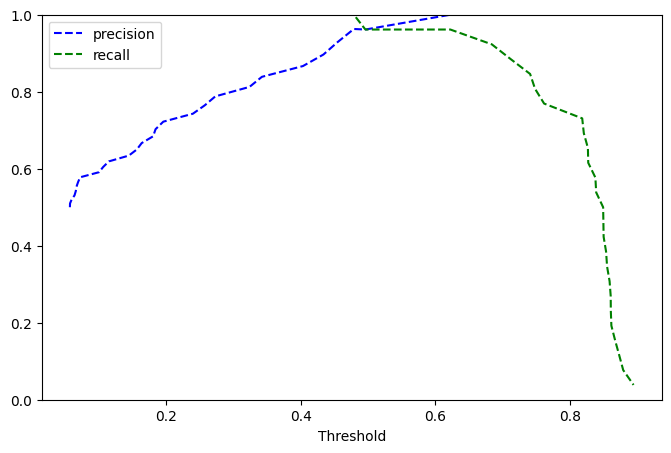

```python
from sklearn.metrics import precision_recall_curve

# predict_proba gives the probability of each observation belonging to each class
y_scores_lg = lg.predict_proba(x_train)

# Precision and Recall curve
precisions_lg, recalls_lg, thresholds_lg = precision_recall_curve(y_train, y_scores_lg[:, 1])

# Plot values of precisions, recalls, and thresholds
plt.figure(figsize = (8, 5))

plt.plot(thresholds_lg, precisions_lg[:-1], 'b--', label = 'precision')
plt.plot(thresholds_lg, recalls_lg[:-1], 'g--', label = 'recall')

plt.xlabel('Threshold')
plt.legend(loc = 'upper left')
plt.ylim([0, 1])

plt.show()
```

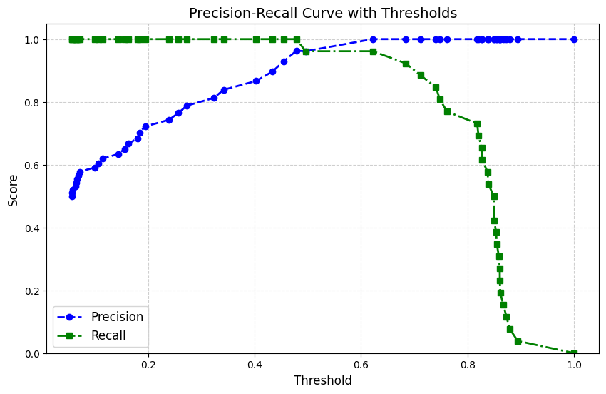

```python
from sklearn.metrics import precision_recall_curve

# Predict probabilities for the positive class (1)
y_scores_lg = lg.predict_proba(x_train)[:, 1]

# Compute Precision-Recall curve
precisions_lg, recalls_lg, thresholds_lg = precision_recall_curve(y_train, y_scores_lg)

# Add a starting threshold of 0 for a smoother curve
thresholds_lg = np.append(thresholds_lg, 1)  # Ensures proper length

# Plot Precision-Recall vs Thresholds
plt.figure(figsize=(10, 6))

plt.plot(thresholds_lg, precisions_lg, 'b--', label='Precision', linewidth=2, marker='o')
plt.plot(thresholds_lg, recalls_lg, 'g-.', label='Recall', linewidth=2, marker='s')

# Formatting
plt.xlabel('Threshold', fontsize=12)
plt.ylabel('Score', fontsize=12)
plt.title('Precision-Recall Curve with Thresholds', fontsize=14)
plt.legend(loc='lower left', fontsize=12)
plt.grid(True, linestyle='--', alpha=0.6)
plt.ylim([0, 1.05])

# Show the plot
plt.show()
```

- Choosing different thresholds can completely change the model's performance. We are looking for "sweet spot" (where they cross).
- Observations
  - Precision and Recall Trade-off:
    - As the threshold increases, precision increases, meaning that the model is making fewer false positive predictions.
    - recall decreases, meaning that the model is missing more actual positives (False Negatives increase).
  - Threshold Effect:
    - At a lower threshold (~0.2-0.4), recall is relatively high, but precision is lower.
    - At a moderate threshold (~0.6), both precision and recall are well-balanced.
    - At a high threshold (~0.8-1.0), precision is very high, but recall drops significantly, meaning the model is too selective and missing many actual positive cases.
- If recall is too low, we risk underestimating strong characters, leading to incorrect battle outcomes.
- If precision is too low, the model might overestimate weaker characters, causing incorrect classifications.

Let's find out the performance of the model at this threshold: .50 (graph output above)

```
              precision    recall  f1-score   support

           0       0.96      1.00      0.98        26
           1       1.00      0.96      0.98        26

    accuracy                           0.98        52
   macro avg       0.98      0.98      0.98        52
weighted avg       0.98      0.98      0.98        52
```

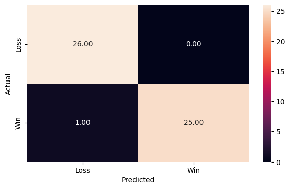

```python
optimal_threshold1 = .5

y_pred_train = lg.predict_proba(x_train)

metrics_score(y_train, y_pred_train[:, 1] > optimal_threshold1)
```

- Observation
  - The classification results remain identical to the first image, meaning the default threshold used in predict() was also 0.5
  - Precision, Recall, and F1-score values did not change.
  - False Negatives (FN) and False Positives (FP) remained the same.

Check the performance on the test data.

```
              precision    recall  f1-score   support

           0       1.00      1.00      1.00         7
           1       1.00      1.00      1.00         6

    accuracy                           1.00        13
   macro avg       1.00      1.00      1.00        13
weighted avg       1.00      1.00      1.00        13
```

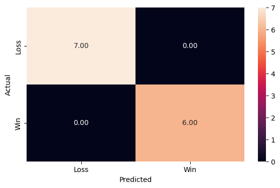

```python
optimal_threshold1 = .5

y_pred_test = lg.predict_proba(x_test)

metrics_score(y_test, y_pred_test[:, 1] > optimal_threshold1)
```

- Observation
  - The results are identical in both cases, meaning that setting the threshold to 0.5 did not change the classification outcome.
  - This suggests that the model is highly confident in its predictions, making clear distinctions between win and loss.

Logistic Observations

Model Performance Comparison

### Training Data Performance:

| Metric | Without Threshold | With Threshold (0.5) |
| --- | --- | --- |
| **Accuracy** | 98% | 98% |
| **Precision** | 96-100% | 96-100% |
| **Recall** | 96-100% | 96-100% |
| **False Positives (FP)** | 0 | 0 |
| **False Negatives (FN)** | 1 | 1 |

### Test Data Performance:

| Metric | Without Threshold | With Threshold (0.5) |
| --- | --- | --- |
| **Accuracy** | 100% | 100% |
| **Precision** | 100% | 100% |
| **Recall** | 100% | 100% |
| **False Positives (FP)** | 0 | 0 |
| **False Negatives (FN)** | 0 | 0 |

**Observations:**

- The model shows **high precision and recall**, suggesting that it correctly classifies winning and losing characters.
- There is **no significant difference** between using direct prediction and applying a 0.5 probability threshold.
- The **False Negative rate (FN)** in the training data is **1 case**, meaning one actual win was predicted as a loss.
- The test data results are **perfect**, with **0 False Negatives and False Positives** in both cases.

**Final Thoughts**

- Since recall is crucial for your dataset (ensuring strong characters are correctly identified as winners), the model is performing **optimally**.
- Future improvements could explore tuning the probability threshold **beyond 0.5** to see if recall can be further optimized.

### K-Nearest Neighbors (K-NN)

[KNN Documentation](https://scikit-learn.org/stable/modules/generated/sklearn.neighbors.KNeighborsClassifier.html)

K-NN uses features from the training data to predict the values of new data points, which means the new data point will be assigned a value based on how similar it is to the data points in the training set.

Note: Scale will need to be changed with KNN because the magnitude at the end will affect the distance/output

The following steps are performed in K-NN:

- Select K
- Calculate distance (Euclidean, Manhattan, etc.)
- Find the K closest neighbors
- Take majority vote for labels

The “K” in the K-NN algorithm is the number of nearest neighbors we wish to take the vote from. Generally, K is taken to be an odd number when the number of classes is even, so as to get a majority vote. Let's say K=3. In that case, we will make a circle with the new data point as the center just as big as enclosing only the three nearest data points on the plane.

But before actually building the model, we need to identify the value of K to be used in K-NN. We will perform the following steps for the same.

```python
# pip install scikit-learn
```

```python
# Import necessary libraries
from sklearn.neighbors import KNeighborsClassifier
from sklearn.model_selection import train_test_split

# %%time
knn = KNeighborsClassifier()

# We select the optimal value of K for which the error rate is the least in the validation data
# Let us loop over a few values of K to determine the optimal value of K

knn_many_split = {}

for k in range(1, 15):
  train_error = []
  test_error = []

  lista = []

  knn = KNeighborsClassifier(n_neighbors = k)

  for i in range(30): # why 30x, 30 iterations took x 1 min 9sec, try as many (more better but time is factor) we take a good average of the 30x
      # Split the training set into a new train and validation sets; size of datsset also important to decide
      # apply GridSearch to find the correct value
      x_train_new, x_val, y_train_new, y_val = train_test_split(x_train, y_train, test_size = 0.20)

      # Fitting K-NN on the training data
      knn.fit(x_train_new, y_train_new)

      # Calculating error on the training data and the validation data
      train_error.append(1 - knn.score(x_train_new, y_train_new))

      test_error.append(1 - knn.score(x_val, y_val))

  lista.append(sum(train_error)/len(train_error))

  lista.append(sum(test_error)/len(test_error))

  knn_many_split[k] = lista
```

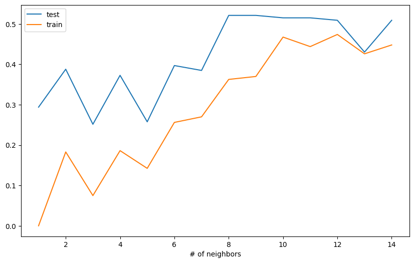

```python
kltrain = []
vltrain = []

for k, v in knn_many_split.items():
    kltrain.append(k)
    vltrain.append(knn_many_split[k][0])

kltest = []
vltest = []

for k, v in knn_many_split.items():
    kltest.append(k)
    vltest.append(knn_many_split[k][1])

# Plotting K vs Error
plt.figure(figsize = (10, 6))

plt.plot(kltest, vltest, label = 'test' )
plt.plot(kltrain, vltrain, label = 'train')

plt.legend()
plt.xlabel('# of neighbors')

plt.show()
```

- Observations
  - The training error (orange line) increases as the number of neighbors increases
  - The test error (blue line) also increases but at a slower rate
  - Initially, the training error is low when k is small, meaning the model is overfitting.
  - As k increases, both training and test errors converge, indicating better generalization
  - Around k=6 to k=8 seems to be a good balance before the model starts underfitting.

```python
# Define K-NN model
knn = KNeighborsClassifier(n_neighbors = 7)
```

```python
# Fitting data to the K-NN model

knn.fit(x_train,y_train)
```

```
KNeighborsClassifier(n_neighbors=7)
```

```
              precision    recall  f1-score   support

           0       0.75      0.92      0.83        26
           1       0.90      0.69      0.78        26

    accuracy                           0.81        52
   macro avg       0.82      0.81      0.81        52
weighted avg       0.83      0.81      0.81        52
```

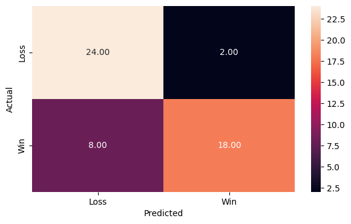

```python
# Checking the performance of K-NN model on the training data
y_pred_train_knn = knn.predict(x_train)

metrics_score(y_train, y_pred_train_knn)
```

```
              precision    recall  f1-score   support

           0       0.78      1.00      0.88         7
           1       1.00      0.67      0.80         6

    accuracy                           0.85        13
   macro avg       0.89      0.83      0.84        13
weighted avg       0.88      0.85      0.84        13
```

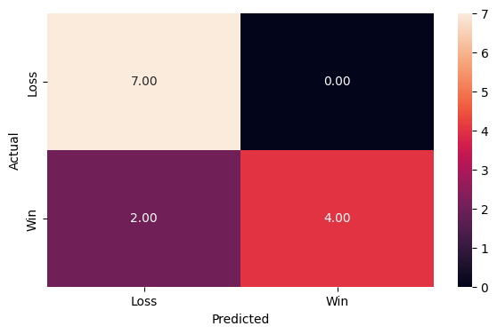

```python
# Checking the performance of K-NN model on the testing data
y_pred_test_knn = knn.predict(x_test)

metrics_score(y_test, y_pred_test_knn)
```

K-Nearest Neighbors (K-NN) Model Comparison

[output not shown]

Observations:

Insights

- You want to minimize False Negatives (FN), meaning that if a character actually wins, the model should correctly predict them as a winner.
- A False Negative (FN) (predicting a loss when the character actually wins) is a major issue because strong fighters might be underestimated, leading to poor battle predictions.
- Higher recall ensures that most actual winners are correctly identified, even if it slightly sacrifices precision.

Using GridSearchCV for Hyperparameter tuning of the model

- Hyperparameter tuning is tricky in the sense that there is no direct way to - - calculate how a change in the hyperparameter value will reduce the loss of your model, so we usually resort to experimentation.
- Grid search is a model tuning technique that attempts to compute the optimum values of hyperparameters.
- It is an exhaustive search that is performed on specific parameter values of a model.
- The parameters of the estimator/model used to apply these methods are optimized by cross-validated grid-search over a parameter grid.

[KNeighborsClassifier Documentation](https://scikit-learn.org/stable/modules/generated/sklearn.neighbors.KNeighborsClassifier.html)

```python
from sklearn.model_selection import GridSearchCV

# %%time
# Parameters to GridSearchCV
params_knn = {'n_neighbors': np.arange(3, 15), 'weights': ['uniform', 'distance'], 'p': [1, 2]}

grid_knn = GridSearchCV(estimator = knn, param_grid = params_knn, scoring = 'recall', cv = 10)

model_knn = grid_knn.fit(x_train,y_train)

knn_estimator = model_knn.best_estimator_
```

```python
knn_estimator
```

```
KNeighborsClassifier(n_neighbors=3, p=1)
```

- n_neighbors = 3
- p = 1

```python
model_knn.best_params_
```

```
{'n_neighbors': 3, 'p': 1, 'weights': 'uniform'}
```

```python
# Fit the best estimator on the training data
knn_estimator.fit(x_train, y_train)
```

```
KNeighborsClassifier(n_neighbors=3, p=1)
```

```
              precision    recall  f1-score   support

           0       0.93      1.00      0.96        26
           1       1.00      0.92      0.96        26

    accuracy                           0.96        52
   macro avg       0.96      0.96      0.96        52
weighted avg       0.96      0.96      0.96        52
```

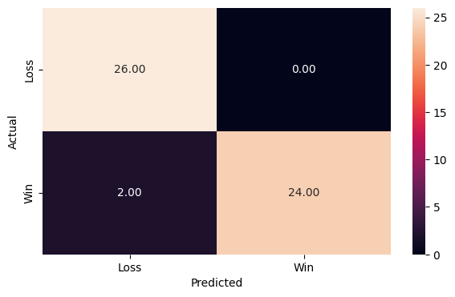

```python
y_pred_train_knn_estimator = knn_estimator.predict(x_train)

metrics_score(y_train, y_pred_train_knn_estimator)
```

```
              precision    recall  f1-score   support

           0       0.78      1.00      0.88         7
           1       1.00      0.67      0.80         6

    accuracy                           0.85        13
   macro avg       0.89      0.83      0.84        13
weighted avg       0.88      0.85      0.84        13
```

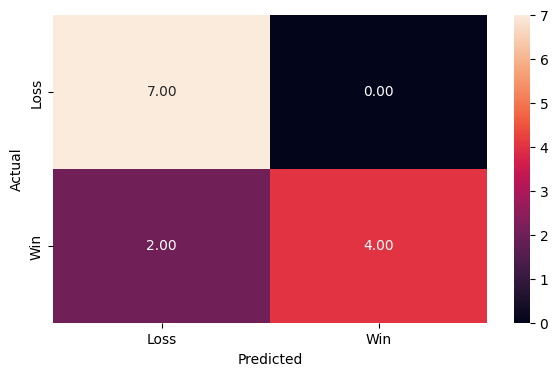

```python
y_pred_test_knn_estimator = knn_estimator.predict(x_test)

metrics_score(y_test, y_pred_test_knn_estimator)
```

### **Comparison of K-NN Estimator Performance**

| **Metric** | **Training Data** | **Test Data** |
| --- | --- | --- |
| **Accuracy** | 96% | 85% |
| **Precision (Class 0)** | 0.93 | 0.78 |
| **Precision (Class 1)** | 1.00 | 1.00 |
| **Recall (Class 0)** | 1.00 | 1.00 |
| **Recall (Class 1)** | 0.92 | 0.67 |
| **F1-Score (Class 0)** | 0.96 | 0.88 |
| **F1-Score (Class 1)** | 0.96 | 0.80 |
| **False Positives (FP)** | 0 | 0 |
| **False Negatives (FN)** | 2 | 2 |

### **Observations**

- The K-NN model performs well on training data with a **96% accuracy** but drops to **85% on test data**, indicating potential **overfitting**.
- The recall for **Class 0 (Loss) remains at 1.00**, meaning all actual losses were predicted correctly.
- The recall for **Class 1 (Win) drops significantly on test data (from 0.92 to 0.67)**, showing that the model is missing winning predictions in real-world cases.
- **False negatives (FN) remain an issue**, particularly in test data, where **2 wins were misclassified as losses**, which is critical for our use case.

### **Insights About Recall**

- Since recall is the priority (minimizing **false negatives**), the **drop in recall for Class 1 (Win) in test data is concerning**.
- The model tends to **underpredict wins**, meaning it may classify strong characters as weaker than they actually are.
- To improve recall:
  - Consider adjusting the **K value** to better balance generalization.
  - Implement **cost-sensitive learning** to penalize misclassified wins more.
  - Try using **weighted K-NN** instead of uniform weighting.
  - Tune the decision **threshold** to favor higher recall.

### Linear Discriminant Analysis (LDA)

Linear discriminant analysis (LDA) is generally used to classify patterns between two classes; however, it can be extended to classify multiple patterns. LDA assumes that all classes are linearly separable and according to this, multiple linear discrimination functions representing several hyperplanes in the feature space are created to distinguish between the classes. If there are two classes, then the LDA draws one hyperplane and projects the data onto this hyperplane in such a way as to maximize the separation of the two categories. This hyperplane is created according to two criteria considered simultaneously:

- Maximizing the distance between the means of two classes.
- Minimizing the variation between each category.

```python
from sklearn.discriminant_analysis import LinearDiscriminantAnalysis

# Fitting the LDA model
lda = LinearDiscriminantAnalysis()

lda.fit(x_train, y_train)
```

```
LinearDiscriminantAnalysis()
```

Checking Model Performance

```
              precision    recall  f1-score   support

           0       1.00      1.00      1.00        26
           1       1.00      1.00      1.00        26

    accuracy                           1.00        52
   macro avg       1.00      1.00      1.00        52
weighted avg       1.00      1.00      1.00        52
```

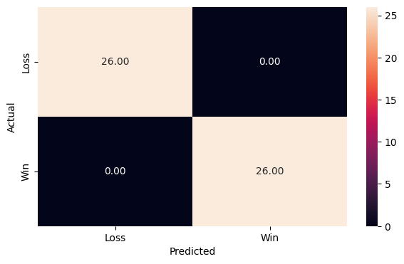

```python
# Checking model performance of LDA
y_pred_train_lda = lda.predict(x_train)

metrics_score(y_train, y_pred_train_lda)
```

- Observations
  - The model has achieved 100% accuracy, meaning it correctly classified all training samples.
- Precision, recall, and F1-score are all 1.00 for both classes (Win/Loss).
- A perfect model on training data suggests potential overfitting, meaning the model might generalize poorly to unseen test data.

Observations from LDA Coefficients Analysis

```python
# Creating the list of column names
cols = X.columns

# Saving coefficients of LDA model
coef_lda = lda.coef_

# Printing the cofficients of LDA
pd.DataFrame(coef_lda, columns = cols).T.sort_values(by = 0, ascending = False)
```

|  | 0 |
| --- | --- |
| Power Level | 1051.312447 |
| Race_Grasshopper | 242.622574 |
| Race_Human | 197.448992 |
| Race_Shape-shifter | 152.275410 |
| Race_Kai | 132.461693 |
| ... | ... |
| Race_Cell Jr. Attack | -138.997098 |
| Race_Death Beam | -138.997098 |
| Race_Tri-Beam | -160.243726 |
| Race_Four Witches Technique | -160.243726 |
| Race_Destruction | -175.878314 |

135 rows × 1 columns

- Observations
  - Key Features with the Highest Impact
    - Power Level has the strongest positive coefficient (1051.31), suggesting that higher power levels increase the likelihood of winning.
  - Key Features with the Most Negative Impact
    - Race_Destruction (-175.87) has the strongest negative coefficient, implying it reduces the likelihood of winning.

Precision-Recall Curve for LDA

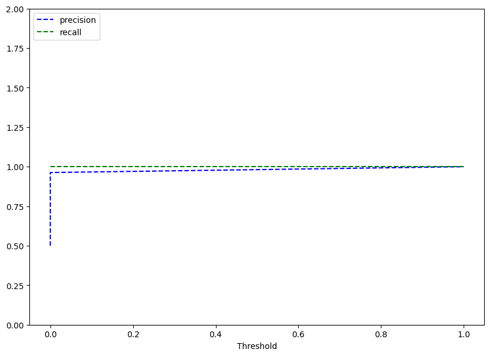

```python
y_scores_lda = lda.predict_proba(x_train) # predict_proba gives the probability of each observation belonging to each class

precisions_lda, recalls_lda, thresholds_lda = precision_recall_curve(y_train, y_scores_lda[:, 1])

# Plot values of precisions, recalls, and thresholds
plt.figure(figsize = (10, 7))

plt.plot(thresholds_lda, precisions_lda[:-1], 'b--', label = 'precision')

plt.plot(thresholds_lda, recalls_lda[:-1], 'g--', label = 'recall')

plt.xlabel('Threshold')

plt.legend(loc = 'upper left')

plt.ylim([0, 2])

plt.show()
```

- Observations
  - Flat Precision & Recall
    - Both precision and recall stay nearly constant at 1 across all thresholds.
    - This suggests that the classifier is predicting with high confidence, assigning almost all positive class probabilities close to 1.
  - Sudden Drop at Threshold ~0
    - There is a sharp drop at the beginning, which indicates that a very small fraction of predictions might be assigned lower probabilities.
    - This could be an effect of imbalanced probability scores.
  - Possible Overconfidence in Predictions
    - Since both metrics remain at 1, the model might be too confident in all classifications, making threshold selection meaningless.
    - This is common with Linear Discriminant Analysis (LDA) when classes are well-separated in feature space.

Check the model performance at this threshold

```python
import numpy as np

# Find the index where precision and recall are closest
diff = np.abs(precisions_lda - recalls_lda)
crossover_idx = np.argmin(diff)

# Find corresponding threshold
crossover_threshold = thresholds_lda[crossover_idx]
print(f"Crossover occurs at threshold: {crossover_threshold}")
```

```
Crossover occurs at threshold: 1.0
```

```
              precision    recall  f1-score   support

           0       0.50      1.00      0.67        26
           1       0.00      0.00      0.00        26

    accuracy                           0.50        52
   macro avg       0.25      0.50      0.33        52
weighted avg       0.25      0.50      0.33        52
```

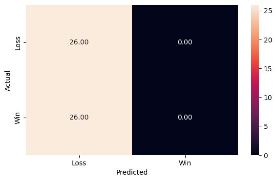

```python
optimal_threshold1 = 1

y_pred_train_lda = lda.predict_proba(x_train)

metrics_score(y_train, y_pred_train_lda[:,1] > optimal_threshold1)
```

- Observations
  - The confusion matrix shows that all instances are classified as Loss (0).
  - This means that the classifier never predicts a Win (1).
  - Since there are no predicted positives, the precision for class 1 (Win) is 0.00.
  - Since there are no TP (true positives) and all 26 positive instances were misclassified as Loss (FN = 26), recall is 0.
  - Since the model always predicts class 0 (Loss), all actual Losses (26) are correctly classified.
  - Since both precision and recall are 0 for class 1, the F1-score (harmonic mean) is also 0.00.

Check the model performance on the test data

```
              precision    recall  f1-score   support

           0       0.54      1.00      0.70         7
           1       0.00      0.00      0.00         6

    accuracy                           0.54        13
   macro avg       0.27      0.50      0.35        13
weighted avg       0.29      0.54      0.38        13
```

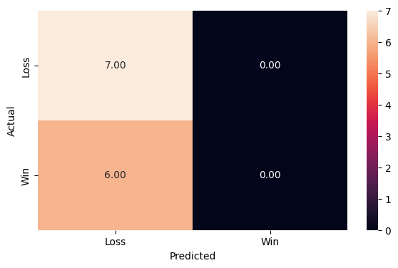

```python
# Checking performance on the test data
optimal_threshold1 = 1

y_pred_test_lda = lda.predict_proba(x_test)

metrics_score(y_test, y_pred_test_lda[:,1] > optimal_threshold1)
```

- Observations
  - The model never predicts class 1 (Win), similar to the training data.
    - This results in 100% recall for class 0, but 0% recall for class 1.
  - All 6 actual wins were misclassified as Loss (FN = 6).
    - This means the model completely fails to identify winning instances.
  - Since both precision and recall are 0 for class 1, the F1-score (harmonic mean) is also 0.00.

### Quadratic Discriminant Analysis (QDA)

- Quadratic discriminant analysis (QDA) is a probabilistic parametric classification technique that represents an evolution of LDA for nonlinear class separations. QDA, like LDA, is based on the hypothesis that the probability density distributions are multivariate normal but, in this case, the dispersion is not the same for all of the categories.

```python
from sklearn.discriminant_analysis import QuadraticDiscriminantAnalysis

# Fitting QDA model
qda = QuadraticDiscriminantAnalysis()

qda.fit(x_train, y_train)
```

```
QuadraticDiscriminantAnalysis()
```

```
              precision    recall  f1-score   support

           0       1.00      1.00      1.00        26
           1       1.00      1.00      1.00        26

    accuracy                           1.00        52
   macro avg       1.00      1.00      1.00        52
weighted avg       1.00      1.00      1.00        52
```

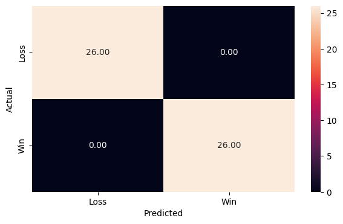

```python
# Checking model performance on the training data
y_pred_train_qda = qda.predict(x_train)

metrics_score(y_train, y_pred_train_qda)
```

```
              precision    recall  f1-score   support

           0       0.86      0.86      0.86         7
           1       0.83      0.83      0.83         6

    accuracy                           0.85        13
   macro avg       0.85      0.85      0.85        13
weighted avg       0.85      0.85      0.85        13
```

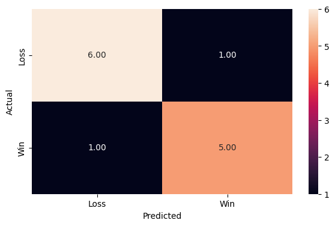

```python
# Checking performance of the model on the test data
y_pred_test_qda = qda.predict(x_test)

metrics_score(y_test, y_pred_test_qda)
```

Model Comparison: Quadratic Discriminant Analysis (QDA)

| Metric | Training Data | Test Data |
| --- | --- | --- |
| **Accuracy** | 100% | 85% |
| **Precision** | 100% | 86% (Class 0), 83% (Class 1) |
| **Recall** | 100% | 86% (Class 0), 83% (Class 1) |
| **F1-score** | 100% | 85% |
| **False Positives (FP)** | 0 | 1 |
| **False Negatives (FN)** | 0 | 1 |

Observations:

- The QDA model performs perfectly on the training data with 100% accuracy, precision, and recall.
- On the test data, performance drops to 85% accuracy, with some misclassifications.
- There is one false positive and one false negative in the test set.
- The precision and recall are relatively balanced, suggesting stable performance but a potential risk of overfitting.

Recommendations:

- Consider tuning hyperparameters or trying different models to improve recall.
- Investigate why false negatives occur and whether feature engineering could help.
- If recall remains a priority, explore threshold adjustments or alternative classifiers.

## Model Comparison and Evaluation

Model Performance on Training and Test Data

[output not shown]

**Recommendations:**

- **Logistic Regression is the best model** for this dataset due to its strong recall and precision.
- **LDA and QDA are strong alternatives**, but adjusting the threshold in LDA significantly reduced recall.
- **K-NN requires fine-tuning** or may not be the best approach for this classification problem.
- **Consider more complex models** such as **Random Forest or XGBoost** for further improvements.

## Feature Importance using SHAP Library

- With the aid of a visualization tool called SHAP, or SHapley Additive exPlanations, a machine learning model's output can be made more understandable. By calculating the contribution of each feature to the prediction, it can be used to explain the prediction by any model. The direction of the relationship (positive or negative) between the predictive variable and the target variable is also indicated by the SHAP values. A technique called SHAP values (SHapley Additive exPlanations), which is based on cooperative game theory, is used to make machine learning models more transparent and understandable.
- In a machine learning setting, a Shapley value is the contribution of a feature value to the difference between the actual prediction and the mean prediction.

```python
!pip install shap
```

SHAP Barplot

- We plot the mean absolute value for each feature column as a bar chart if an Explainer with many samples is passed.
- We determine the mean absolute SHAP values across all observations for each feature. Since we do not want positive and negative numbers to cancel one another out, we take the absolute values. A mean SHAP plot will allow us to visualize the aggregated SHAP values.
- SHAP value helps us quantify feature's contribution towards a prediction. SHAP value closer to zero means the feature contributes little to the prediction whereas SHAP value away from zero indicates the feature contributes more. So, large positive/negative SHAP values are found in features that significantly affect the model's predictions.

```python
# Importing the SHAP library
import shap as sh
```

```python
%%time
# Fitting the Explainer
explainer = sh.Explainer(knn_estimator.predict, x_test)

# Calculating the SHAP values. The below code might take some time to run.
shap_values = explainer(x_test)
```

```
PermutationExplainer explainer: 14it [00:15,  1.20s/it]
```

```
CPU times: user 12.7 s, sys: 589 ms, total: 13.3 s
Wall time: 15.6 s
```

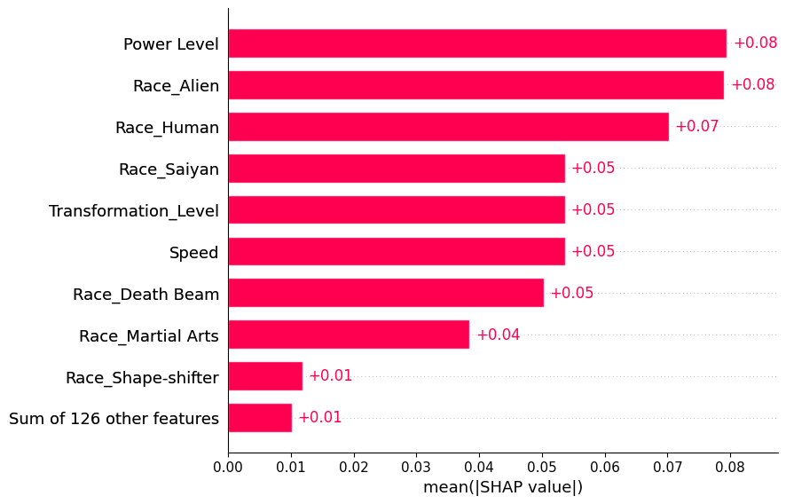

```python
sh.plots.bar(shap_values)
```

- By default the bar plot only shows a maximum of ten bars, but this can be controlled with the max_display parameter

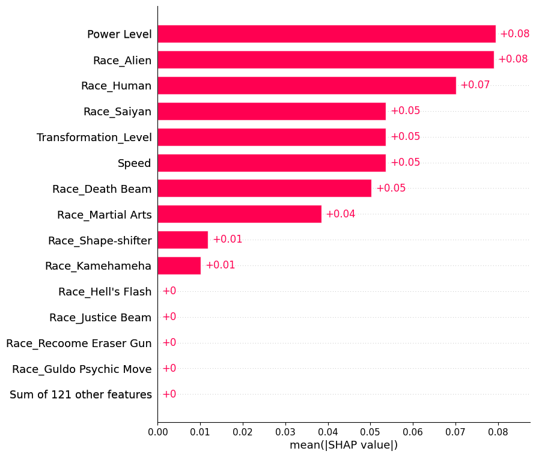

```python
sh.plots.bar(shap_values, max_display=15)
```

- Top Influencing Features:
  - The most impactful features for predicting battle outcomes are Power Level and Race_Alien, both having a SHAP value of +0.08.
  - Race_Human follows closely with a SHAP value of +0.07, indicating a significant impact.
  - Other key features include Race_Saiyan, Transformation_Level, Speed, and Race_Death Beam, all contributing +0.05.
- Lesser Impact Features:
  - Martial Arts plays a moderate role with a SHAP value of +0.04.
  - Race_Shape-shifter and Kamehameha show minor influence with SHAP values of +0.01.
  - Some features like Race_Hell's Flash, Race_Justice Beam, and Recoome Eraser Gun contribute 0, implying they do not significantly influence predictions.
- Example:
  - If a character has a high Power Level (+0.08 SHAP value) and belongs to the Race_Alien (+0.08 SHAP value), they are more likely to win battles.
  - A character with high Speed (+0.05 SHAP value) but belonging to a race with lower SHAP values (e.g., Race_Justice Beam, 0.00) may have a neutral or lesser impact on their battle success.
- Conclusion:
  - The SHAP analysis confirms that Power Level, Race_Alien, and Race_Human are key determinants in battle outcomes. If optimizing for better predictions, focusing on these variables will enhance model performance.

Summary Plot

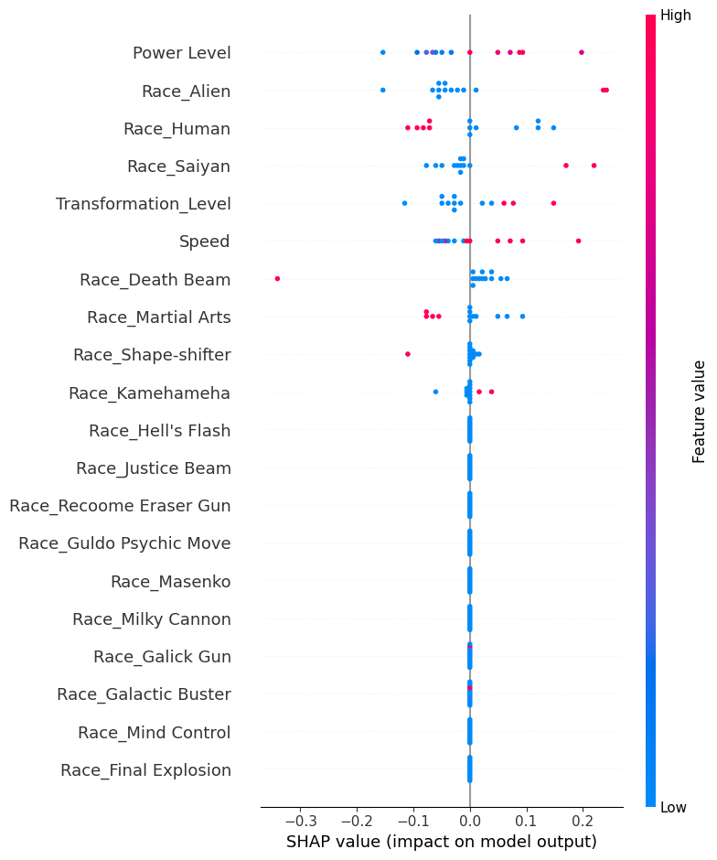

```python
sh.summary_plot(shap_values)
```

Force Plot

- The SHAP force plot shows you exactly which feature had the most influence on the model's prediction for a single observation.
  - issue of using this is feature for only one e.g., x_test
  - this does it one one

The below graph explains a single prediction from the test set.

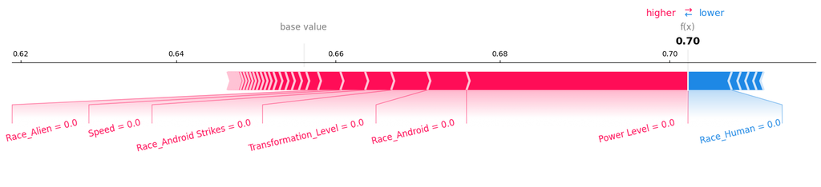

```python
explainer = sh.KernelExplainer(knn.predict_proba, x_train)

shap_values1 = explainer.shap_values(x_test.iloc[0,:])

sh.force_plot(explainer.expected_value[0], shap_values1[:, 0], x_test.iloc[0,:], matplotlib = True, text_rotation=13, link='logit')
```

## Conclusion & Recommendations

Conclusion

Recommendations

```python
# google

path_ipynb = '/content/drive/MyDrive/My DS DA/Dragon Ball Z/5 Supervised Learning Classification.ipynb'
notebook_path = path_ipynb

!jupyter nbconvert --to html "{notebook_path}"

from google.colab import files
path_html = '/content/drive/MyDrive/My DS DA/Dragon Ball Z/5 Supervised Learning Classification.html'

files.download(path_html)
```

```
[NbConvertApp] Converting notebook /content/drive/MyDrive/My DS DA/Dragon Ball Z/5 Supervised Learning Classification.ipynb to html
[NbConvertApp] WARNING | Alternative text is missing on 23 image(s).
[NbConvertApp] Writing 1541671 bytes to /content/drive/MyDrive/My DS DA/Dragon Ball Z/5 Supervised Learning Classification.html
```